# Reproducible Research Course Project 1

David Kochar

September 16, 2017

```r
library(knitr)
knitr::opts_chunk$set(fig.width=8, fig.height=4, fig.path='figures/RepDataAssignment1_', echo=TRUE, warning=FALSE, message=FALSE)
```

### Introduction

It is now possible to collect a large amount of data about personal movement using activity monitoring devices such as a Fitbit, Nike Fuelband, or Jawbone Up. These type of devices are part of the âquantified selfâ movement â a group of enthusiasts who take measurements about themselves regularly to improve their health, to find patterns in their behavior, or because they are tech geeks. But these data remain under-utilized both because the raw data are hard to obtain and there is a lack of statistical methods and software for processing and interpreting the data.

### Data

This analysis makes use of data from a personal activity monitoring device. This device collects data at 5 minute intervals through out the day. The data consists of two months of data from an anonymous individual collected during the months of October and November, 2012 and include the number of steps taken in 5 minute intervals each day. The source of the data is found [here](https://d396qusza40orc.cloudfront.net/repdata%2Fdata%2Factivity.zip).

### Analysis

The analysis will cover:

- Data loading and preparation steps
- The distribution of the total number of steps taken each day
- The mean and median number of steps taken each day
- A time series plot of the average number of steps taken
- The 5-minute interval that, on average, contains the maximum number of steps
- Code to describe and show a strategy for imputing missing data
- A distribution of the total number of steps taken each day after missing values are imputed
- A Panel plot comparing the average number of steps taken per 5-minute interval across weekdays and weekends

### Prepare Workspace and Load Libraries

```r
#Clear variables
rm ( list = ls ( all = TRUE ) )
#Get and set working directory
setwd ( getwd () )
install.packages("dplyr", repos = "http://cran.us.r-project.org")
```

```r
install.packages("ggplot2", repos = "http://cran.us.r-project.org")
install.packages("scales", repos = "http://cran.us.r-project.org")
install.packages("lubridate", repos = "http://cran.us.r-project.org")
suppressWarnings ( suppressMessages ( library ( dplyr) ) )
suppressWarnings ( suppressMessages ( library ( ggplot2) ) )
suppressWarnings ( suppressMessages ( library ( scales) ) )
suppressWarnings ( suppressMessages ( library ( lubridate) ) )
```

### Load the Data

```r
#Download, unzip, load, and prepare the data set
temp <- tempfile ()
download.file ( "https://d396qusza40orc.cloudfront.net/repdata%2Fdata%2Factivity.zip", temp )
unzip ( temp )
unlink ( temp )
Activity <- as.data.frame ( read.csv ( file = "activity.csv", header = TRUE, sep = "," ) )
#Convert factor date to actual date
Activity <- Activity %>%
            mutate ( date = as.Date (date, format = "%Y-%m-%d") )
```

### Plot a histogram to visualize the total number of steps taken each day

#### Subset the Activity Data into Total Steps Per Day

```r
StepsPerDay <- Activity %>%
               group_by(date) %>%
               summarise ( steps = sum ( steps ) )
```

#### Intialize a Histogram to Create Frequency Labels

```r
#Initialize histogram
ActivityHist <- hist ( StepsPerDay$steps )

#Create frequency label variable
ActivityHist$density = ( ActivityHist$counts / sum ( ActivityHist$counts ) ) * 100

#Create vector for frequency labels
BarLabels <- paste ( round ( ActivityHist$density ), "%", sep = "" )
```

#### Plot Formatted Histogram

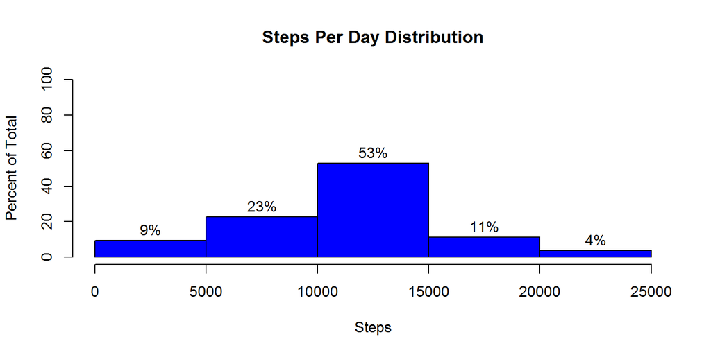

```r
#Create the histogram
plot ( ActivityHist,
      freq = FALSE,
      main = "Steps Per Day Distribution",
      xlab = "Steps",
      ylab = "Percent of Total",
      col  = "blue",
      ylim = c( 0, 100 ),
      labels = BarLabels )
```

### Calculate the Mean and Median Steps Taken Each Day

```r
MeanStepsPerDay <-  mean ( StepsPerDay$steps, na.rm = TRUE )
MedianStepsPerDay <- median ( StepsPerDay$steps, na.rm = TRUE )
```

Mean Steps Per Day: 10766.1886792453

Median Steps Per Day: 10765

### Plot a Time-Series of Average Steps Per Interval

#### Subset the Activity Data Into Average Steps Per Interval

```r
StepsPerInterval <- Activity %>%
                    group_by(interval) %>%
                    summarise ( steps = mean ( steps, na.rm = TRUE ) )
```

#### Plot the Time Series

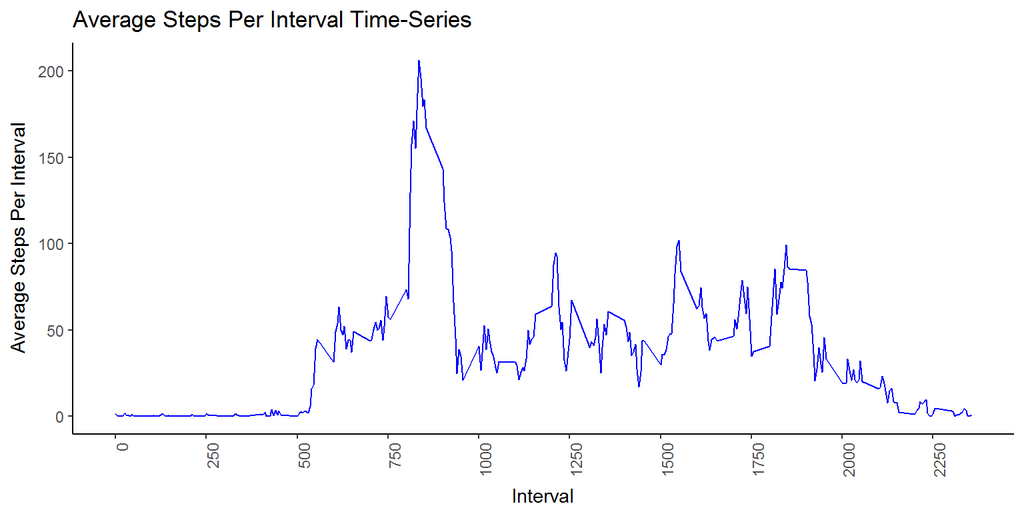

```r
ggplot(data = StepsPerInterval, aes(x=interval, y=steps, group=1)) +
  geom_line ( colour = "blue" ) +
    labs(x = "Interval", y = "Average Steps Per Interval") +
    ggtitle( "Average Steps Per Interval Time-Series" ) +
   scale_x_continuous( breaks = seq ( min ( StepsPerInterval$interval ), max ( StepsPerInterval$interval ), by = 250 ) ) +
  theme(axis.text.x=element_text(angle=90, hjust=1), panel.grid.major =     element_blank(),   panel.grid.minor = element_blank(), panel.background = element_blank(), axis.line = element_line(colour = "black"))
```

### Determine the Interval with the Maximum Number of Steps

```r
MaxStepsInterval <- StepsPerInterval %>%
                    top_n ( n=1 ) %>%
                    select ( interval )
```

On average across all the days in the dataset, the 835 interval contains the maximum number of steps.

#### Determine the total number of missing values in the dataset

```r
TotalActivityNA <- sum (is.na ( Activity ) )
```

The total number of missing values in the dataset is 2304.

### Plot a Histogram with the Imputed Dataset

#### Impute Missing Values in the Dataset and Create a New Data Set with Imputed Values

To impute missing values, we will apply the respective weekly means to all NA values for the week in which they occur

```r
#The imputing strategy is to apply the weekly means to all NA values
ActivityFilled <- Activity %>%
                  mutate ( WeekBeginDate = paste ( year ( date ), week (date ) ) )   %>%
                  group_by ( WeekBeginDate ) %>%
                  mutate ( StepsFilled = ifelse ( is.nan ( mean ( steps, na.rm = TRUE  ) ), 0, mean ( steps, na.rm = TRUE  ) ) )                    %>%
                  ungroup() %>%
                  mutate ( steps = ifelse ( is.na ( steps ), StepsFilled, steps ) )
```

#### Subset the Activity Data into Total Steps Per Day

```r
StepsPerDay2 <- ActivityFilled %>%
               group_by(date) %>%
               summarise ( steps = sum ( steps ) )
```

#### Intialize a Histogram to Create Frequency Labels

```r
#Initialize histogram
ActivityHist2 <- hist ( StepsPerDay2$steps )

#Create frequency label variable
ActivityHist2$density = ( ActivityHist2$counts / sum ( ActivityHist2$counts ) ) * 100

#Create vector for frequency labels
BarLabels2 <- paste ( round ( ActivityHist2$density ), "%", sep = "" )
```

#### Plot Formatted Histogram

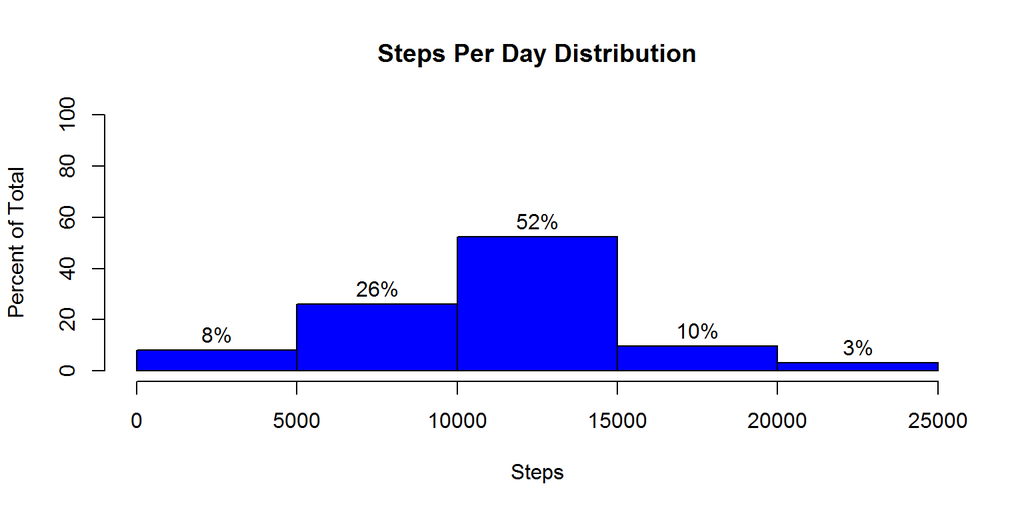

```r
#Create the histogram
plot.new()
plot ( ActivityHist2,
      freq = FALSE,
      main = "Steps Per Day Distribution",
      xlab = "Steps",
      ylab = "Percent of Total",
      col  = "blue",
      ylim = c( 0, 100 ),
      labels = BarLabels2 )
```

### Calculate the Mean and Median Steps Taken Each Day from the Imputed Data Set

```r
MeanStepsPerDay2 <-  mean ( StepsPerDay2$steps, na.rm = TRUE )
MedianStepsPerDay2 <- median ( StepsPerDay2$steps, na.rm = TRUE )
```

Mean Steps Per Day: 10642.7581967213

Median Steps Per Day: 10571

#### Subset the Activity Data Into Average Steps Per Interval for Weekdays and Weekends

```r
StepsPerIntervalWday <- Activity %>%
                        mutate ( IsWeekDay = ifelse ( wday(date) == c(1,7), "Weekend", "Weekday") ) %>%
                        group_by ( IsWeekDay, interval ) %>%
                        summarise ( steps = mean ( steps, na.rm = TRUE ) )
```

#### Plot the Time Series

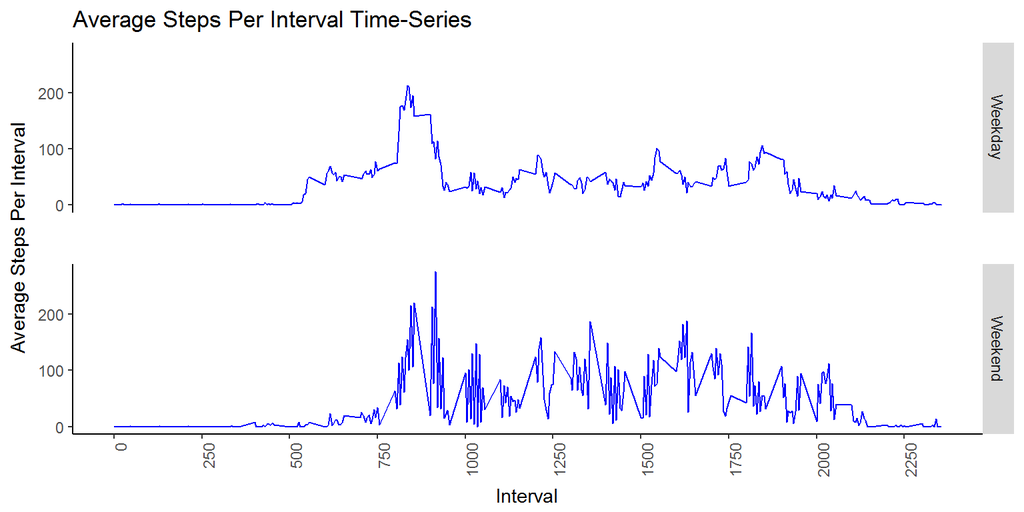

```r
ggplot(data = StepsPerIntervalWday, aes(x=interval, y=steps, group=1)) +
  geom_line ( colour = "blue" ) +
  facet_grid ( IsWeekDay ~ . ) +
    labs(x = "Interval", y = "Average Steps Per Interval") +
    ggtitle( "Average Steps Per Interval Time-Series" ) +
   scale_x_continuous( breaks = seq ( min ( StepsPerIntervalWday$interval ), max ( StepsPerIntervalWday$interval ), by = 250 ) ) +
  theme(axis.text.x=element_text(angle=90, hjust=1), panel.grid.major =     element_blank(),   panel.grid.minor = element_blank(), panel.background = element_blank(), axis.line = element_line(colour = "black")) +
theme(panel.spacing = unit(2, "lines"))
```